# Business objective

The model predicts if a prospective client will purchase a car or not. This model predict the probability of a client purchasing a car using the client features such as gender, age, and annual salary. The model can support businesses to find out if their client will purchase a car or not.

## Import necessary Python Packages

```python
# import libraries
import pandas as pd
import numpy as np
import matplotlib.pyplot as plt
import seaborn as sns
from sklearn.preprocessing import OneHotEncoder
from sklearn.preprocessing import StandardScaler
from sklearn import model_selection
from sklearn.linear_model import LogisticRegression
from sklearn.model_selection import train_test_split
from sklearn import metrics
from sklearn.metrics import classification_report
from sklearn.metrics import confusion_matrix
import missingno as msno

%matplotlib inline
```

## Get the data

### Import the Dataset

```python
# load the dataset
car_data = pd.read_csv('car_data.csv')
car_data.head()
```

|  | User ID | Gender | Age | AnnualSalary | Purchased |
| --- | --- | --- | --- | --- | --- |
| 0 | 385 | Male | 35 | 20000 | 0 |
| 1 | 681 | Male | 40 | 43500 | 0 |
| 2 | 353 | Male | 49 | 74000 | 0 |
| 3 | 895 | Male | 40 | 107500 | 1 |
| 4 | 661 | Male | 25 | 79000 | 0 |

## Explore the Dataset

```python
# dataset info
car_data.info()
```

```
<class 'pandas.core.frame.DataFrame'>
RangeIndex: 1000 entries, 0 to 999
Data columns (total 5 columns):
 #   Column        Non-Null Count  Dtype
---  ------        --------------  -----
 0   User ID       1000 non-null   int64
 1   Gender        1000 non-null   object
 2   Age           1000 non-null   int64
 3   AnnualSalary  1000 non-null   int64
 4   Purchased     1000 non-null   int64
dtypes: int64(4), object(1)
memory usage: 39.2+ KB
```

```python
# dataset dimension
print("There are {} rows and {} columns in the dataset.".format(car_data.shape[0], car_data.shape[1]))
```

```
There are 1000 rows and 5 columns in the dataset.
```

```python
# check the columns
car_data.columns
```

```
Index(['User ID', 'Gender', 'Age', 'AnnualSalary', 'Purchased'], dtype='object')
```

```python
# drop the User ID column.
car_data.drop(columns=['User ID'], inplace=True)
```

```python
# summary statistics
car_data.describe().transpose()
```

|  | count | mean | std | min | 25% | 50% | 75% | max |
| --- | --- | --- | --- | --- | --- | --- | --- | --- |
| Age | 1000.0 | 40.106 | 10.707073 | 18.0 | 32.0 | 40.0 | 48.0 | 63.0 |
| AnnualSalary | 1000.0 | 72689.000 | 34488.341867 | 15000.0 | 46375.0 | 72000.0 | 90000.0 | 152500.0 |
| Purchased | 1000.0 | 0.402 | 0.490547 | 0.0 | 0.0 | 0.0 | 1.0 | 1.0 |

```python
# correlation between the variables
car_data.corr()
```

|  | Age | AnnualSalary | Purchased |
| --- | --- | --- | --- |
| Age | 1.000000 | 0.166042 | 0.616036 |
| AnnualSalary | 0.166042 | 1.000000 | 0.364974 |
| Purchased | 0.616036 | 0.364974 | 1.000000 |

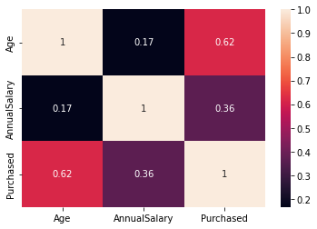

```python
sns.heatmap(car_data.corr(), annot=True);
```

The closer the value to 1, the stronger the correlation between the variables.

```python
# check for missing rows
car_data.isnull().sum()
```

```
Gender          0
Age             0
AnnualSalary    0
Purchased       0
dtype: int64
```

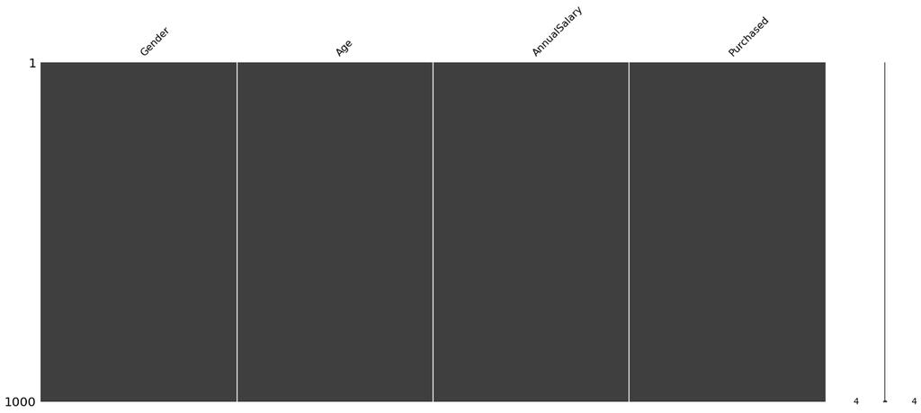

```python
msno.matrix(car_data)
plt.show()
```

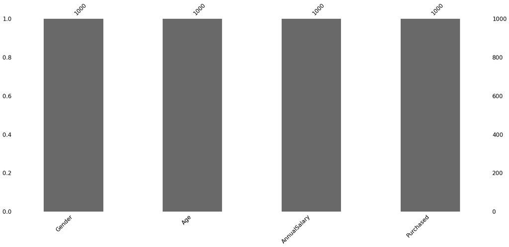

```python
msno.bar(car_data)
plt.show()
```

The above plots showed that there is no missing values in the dataset.

## Functions to explore each feature

```python
# function that will return value count and frequency for each observation within a feature
def value_cnt_norm_cal(df,feature):
    ftr_value_cnt = df[feature].value_counts()
    ftr_value_cnt_norm = df[feature].value_counts(normalize=True) * 100
    ftr_value_cnt_concat = pd.concat([ftr_value_cnt, ftr_value_cnt_norm], axis=1)
    ftr_value_cnt_concat.columns = ['Count', 'Frequency (%)']
    return ftr_value_cnt_concat
```

```python
# function to display information about the feature
def gen_info_feat(df,feature):
        match feature:
            case 'Age':
                print('Description:\n{}'.format(df[feature].describe()))
                print('*'*50)
                print('Object type:\n{}'.format(df[feature].dtype))
            case _:
                print('Description:\n{}'.format(df[feature].describe()))
                print('*'*50)
                print('Object type:\n{}'.format(df[feature].dtype))
                print('*'*50)
                value_cnt = value_cnt_norm_cal(df,feature)
                print('Value count:\n{}'.format(value_cnt))
```

```python
# function to create a pie chart plot
def create_pie_plot(df, feature):
    ratio_size = value_cnt_norm_cal(df, feature)
    ratio_size_len = len(ratio_size.index)
    ratio_list = []
    for i in range(ratio_size_len):
        ratio_list.append(ratio_size.iloc[i]['Frequency (%)'])
    fig, ax = plt.subplots(figsize=(8,8))
    # %1.2f%% display decimals in the pie chart with 2 decimal places
    plt.pie(ratio_list, labels=ratio_size.index, autopct='%1.2f%%', startangle=90, wedgeprops={'edgecolor' :'black'})
    plt.title('Pie chart of {}'.format(feature), fontsize=20)
    plt.legend(loc='best')
    plt.axis('equal')
    return plt.show()
```

```python
# function to create a bar chart plot
def create_bar_plot(df, feature):
    fig, ax  = plt.subplots(figsize=(6,10))
    sns.set_theme(style='whitegrid')
    sns.barplot(x=value_cnt_norm_cal(df, feature).index, y=value_cnt_norm_cal(df,feature).values[:,0])
    plt.xlabel('{}'.format(feature))
    plt.ylabel('Count')
    plt.title('{} count'.format(feature), fontsize=20)
    return plt.show()
```

```python
# create to create a box plot
def create_box_plot(df, feature):
    fig, ax = plt.subplots(figsize=(2,8))
    sns.set_theme(style='whitegrid')
    sns.boxplot(y=df[feature])
    plt.title('{} distribution(Boxplot)'.format(feature), fontsize=20)
    return plt.show()
```

```python
# function to create a histogram plot
def create_hist_plot(df, feature, the_bins=50):
    fig, ax = plt.subplots(figsize=(18,10))
    sns.set_theme(style='whitegrid')
    sns.histplot(df[feature], bins=the_bins, kde=True)
    plt.title('{} distribution'.format(feature), fontsize=20)
    return plt.show()
```

```python
# purchase vs non_purchase individuals compared on a box plot
def purchase_nonpurchase_box_plot(df, feature):
    print(df.groupby('Purchased')[feature].mean())
    fig, ax = plt.subplots(figsize=(5,8))
    sns.set_theme(style='whitegrid')
    sns.boxplot(y=df[feature], x=df['Purchased'])
    plt.xticks(ticks=[0,1], labels=['no', 'yes'])
    plt.title('Purchase individuals grouped by {}'.format(feature), fontsize=20)
    return plt.show()
```

```python
# purchase vs non_purchase individuals compared on a bar plot
def purchase_nonpurchase_bar_plot(df, feature):
    purchase_grp = df.groupby(feature)['Purchased'].sum()
    purchase_grp_srt = purchase_grp.sort_values(ascending=False)
    print(dict(purchase_grp_srt))
    fig, ax = plt.subplots(figsize=(6,10))
    sns.set_theme(style='whitegrid')
    sns.barplot(x=purchase_grp_srt.index, y=purchase_grp_srt.values)
    ax.set_xticklabels(labels=purchase_grp_srt.index, ha='right')
    plt.ylabel('Count')
    plt.title('Purchase individuals count grouped by {}'.format(feature), fontsize=20)
    return plt.show()
```

## Univariate Analysis

### Gender

```python
gen_info_feat(car_data, 'Gender')
```

```
Description:
count       1000
unique         2
top       Female
freq         516
Name: Gender, dtype: object
Object type:
object
Value count:
        Count  Frequency (%)
Female    516           51.6
Male      484           48.4
```

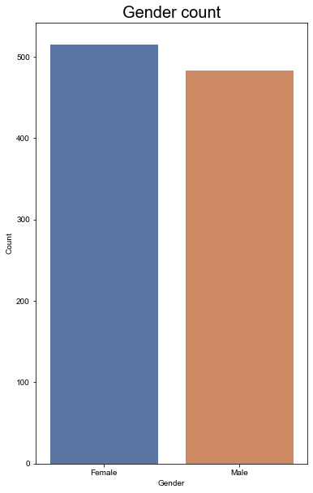

```python
create_bar_plot(car_data, 'Gender')
```

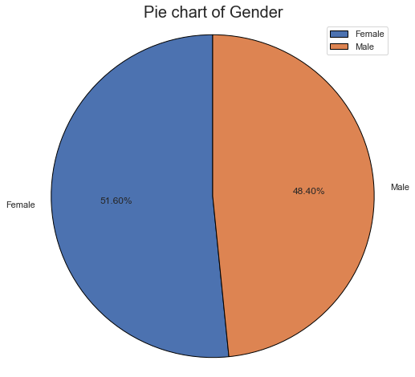

```python
create_pie_plot(car_data, 'Gender')
```

Interpretation:

- We have more females clients than male (52%, 48%)

```
{'Female': 219, 'Male': 183}
```

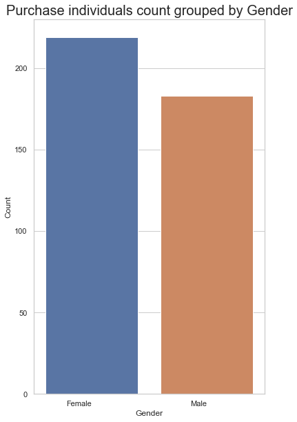

```python
purchase_nonpurchase_bar_plot(car_data, 'Gender')
```

### Age

```python
gen_info_feat(car_data, 'Age')
```

```
Description:
count    1000.000000
mean       40.106000
std        10.707073
min        18.000000
25%        32.000000
50%        40.000000
75%        48.000000
max        63.000000
Name: Age, dtype: float64
Object type:
int64
```

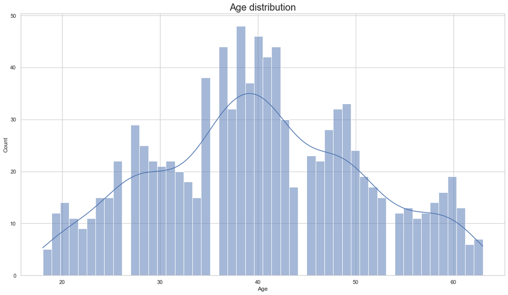

```python
create_hist_plot(car_data, 'Age')
```

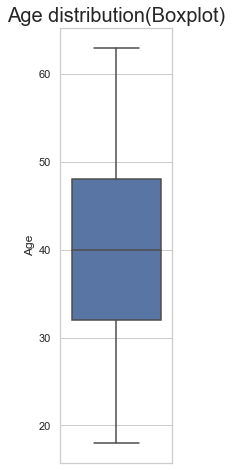

```python
create_box_plot(car_data, 'Age')
```

```
Purchased
0    34.700669
1    48.146766
Name: Age, dtype: float64
```

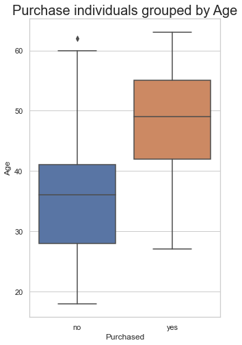

```python
purchase_nonpurchase_box_plot(car_data, 'Age')
```

### Annual Salary

```python
gen_info_feat(car_data, 'AnnualSalary')
```

```
Description:
count      1000.000000
mean      72689.000000
std       34488.341867
min       15000.000000
25%       46375.000000
50%       72000.000000
75%       90000.000000
max      152500.000000
Name: AnnualSalary, dtype: float64
Object type:
int64
Value count:
        Count  Frequency (%)
81500      18            1.8
73500      17            1.7
76500      14            1.4
80500      12            1.2
62500      12            1.2
...       ...            ...
94500       1            0.1
139000      1            0.1
104500      1            0.1
117500      1            0.1
101000      1            0.1

[247 rows x 2 columns]
```

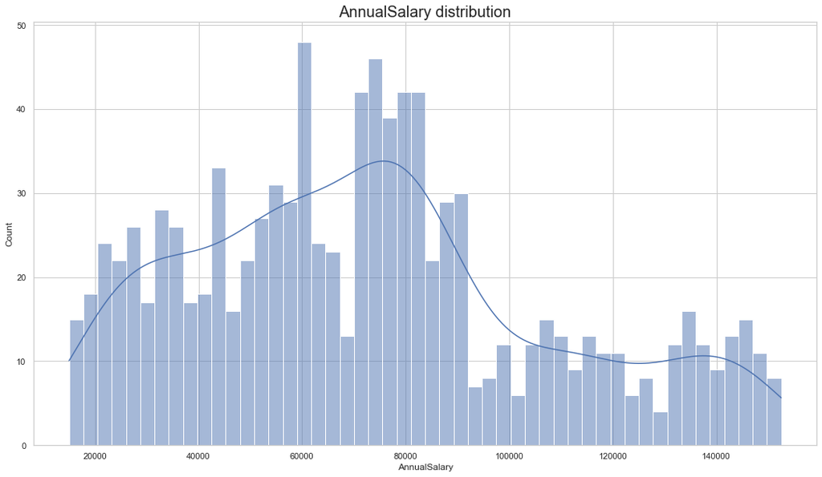

```python
create_hist_plot(car_data, 'AnnualSalary')
```

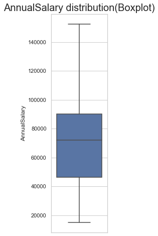

```python
create_box_plot(car_data, 'AnnualSalary')
```

```
Purchased
0    62373.745819
1    88033.582090
Name: AnnualSalary, dtype: float64
```

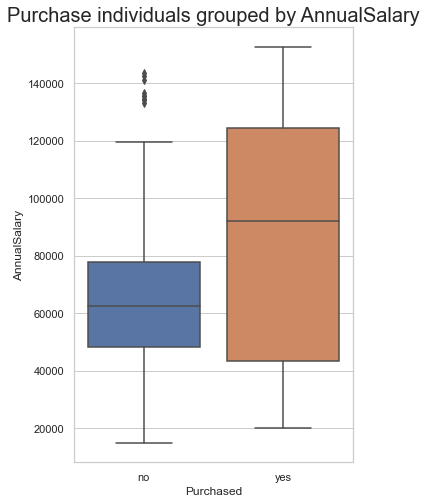

```python
purchase_nonpurchase_box_plot(car_data, 'AnnualSalary')
```

Interpretation:

- The clients minimun Annual salary is 15,000 and the maximum value of 152,500.
- The average Annual salary of clients who purchased a car is 88,034 while the average of clients who didn't purchase is 62,374

## Bivariate Analysis

### Numerical vs Numerical Features (Correlation & Scatter Plots)

### Scatter Plots

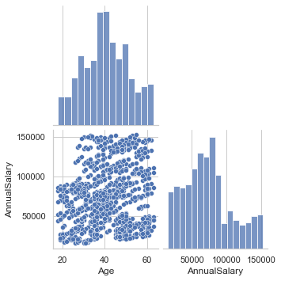

```python
sns.pairplot(car_data[['Age', 'AnnualSalary']], corner=True)
plt.show()
```

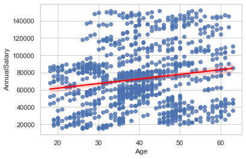

```python
sns.regplot(x='Age', y='AnnualSalary',data=car_data, line_kws={'color': 'red'})
plt.show()
```

### Correlation analysis

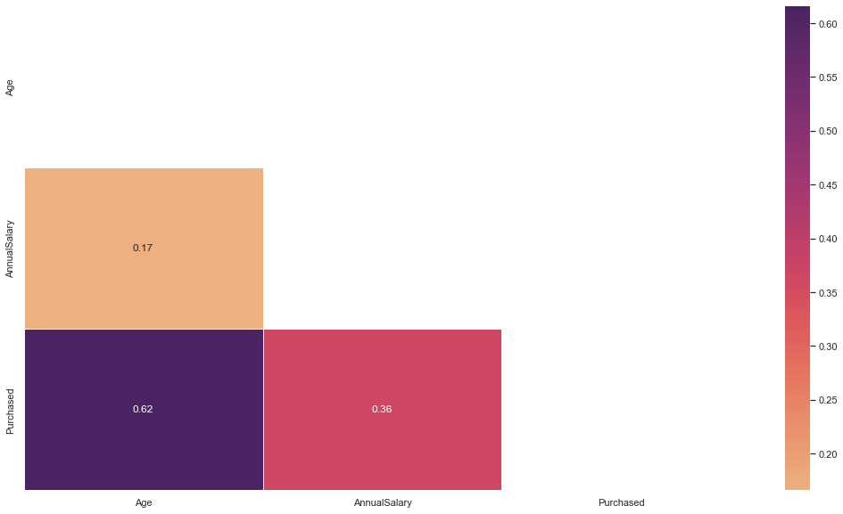

```python
# correlation analysis with heatmap, after dropping the has a mobile phone with the target feature as int
car_data_corr_no_gender = pd.concat([car_data.drop(['Gender','Purchased'], axis=1), car_data['Purchased']],axis=1).corr()
# Get the lower triangle of the correlation matrix
# Generate a mask for the upper triangle
mask = np.zeros_like(car_data_corr_no_gender, dtype='bool')
mask[np.triu_indices_from(mask)] = True
# Set up the matplotlib figure
fig, ax = plt.subplots(figsize=(18,10))
# seaborn heatmap
sns.heatmap(car_data_corr_no_gender, annot=True, cmap='flare',mask=mask, linewidths=.5)
# plot the heatmap
plt.show()
```

Interpretation:

- The age is highly correlated with the target feature(purchased). The older the clients is, the most likely of purchasing a car.
- Annual salary has some correlation with the target feature(purchased). The higher the annual salary the higher the chances of purchasing a car.

## Prepare the data

### One hot encoding for Gender.

```python
one_hot_enc = OneHotEncoder()
one_hot_enc_gender = pd.DataFrame(one_hot_enc.fit_transform(car_data[['Gender']]).toarray())
car_data = car_data.join(one_hot_enc_gender)
car_data = car_data.rename(columns={0:'Gender_F', 1:'Gender_M'})
car_data
```

|  | Gender | Age | AnnualSalary | Purchased | Gender_F | Gender_M |
| --- | --- | --- | --- | --- | --- | --- |
| 0 | Male | 35 | 20000 | 0 | 0.0 | 1.0 |
| 1 | Male | 40 | 43500 | 0 | 0.0 | 1.0 |
| 2 | Male | 49 | 74000 | 0 | 0.0 | 1.0 |
| 3 | Male | 40 | 107500 | 1 | 0.0 | 1.0 |
| 4 | Male | 25 | 79000 | 0 | 0.0 | 1.0 |
| ... | ... | ... | ... | ... | ... | ... |
| 995 | Male | 38 | 59000 | 0 | 0.0 | 1.0 |
| 996 | Female | 47 | 23500 | 0 | 1.0 | 0.0 |
| 997 | Female | 28 | 138500 | 1 | 1.0 | 0.0 |
| 998 | Female | 48 | 134000 | 1 | 1.0 | 0.0 |
| 999 | Female | 44 | 73500 | 0 | 1.0 | 0.0 |

1000 rows × 6 columns

```python
car_data.shape
```

```
(1000, 6)
```

## Build the Model

```python
# split the train data into X and y (target)
X = car_data[['Age', 'AnnualSalary', 'Gender_F', 'Gender_M']]  # independent features
Y = car_data['Purchased']                                      # dependent feature
```

```python
# split the dataset into train and test
X_train, X_test, y_train, y_test = train_test_split(X,Y, test_size=0.4, random_state=100)
```

## Feature Scaling

```python
sc = StandardScaler()
X_train = sc.fit_transform(X_train)
X_test = sc.transform(X_test)
```

```python
# fit Logistic Regression
classifier = LogisticRegression()
classifier.fit(X_train, y_train)
```

```
LogisticRegression()
```

```python
# predict likelihood of purchase.
y_pred = classifier.predict(X_test)
```

## Evaluate the Model's Performance

### Classification Report

```python
print('Acurracy: {}'.format(metrics.accuracy_score(y_test, y_pred)))
print('Recall: {}'.format(metrics.recall_score(y_test, y_pred, zero_division=1)))
print('Precision: {}'.format(metrics.precision_score(y_test, y_pred, zero_division=1)))
print('CL Report: {}'.format(metrics.classification_report(y_test, y_pred, zero_division=1)))
```

```
Acurracy: 0.81
Recall: 0.6923076923076923
Precision: 0.7941176470588235
CL Report:               precision    recall  f1-score   support

           0       0.82      0.89      0.85       244
           1       0.79      0.69      0.74       156

    accuracy                           0.81       400
   macro avg       0.81      0.79      0.80       400
weighted avg       0.81      0.81      0.81       400
```

- Accuracy is the score used to evaluate the model's performance. The higher it is, the better.
- Recall measures the model's ability to correctly predict the true positive values.
- Precision is the ratio of true positives to the sum of both true and false positives.
- F-Score combines precision and recall into one metric. Ideally, its value should be closeest to 1, the better.
- Support is the number of actual occurences of each class in the dataset.

## The model's performance in percent:

- Accuracy: 81%
- Recall: 69%
- Precision: 79%

We can safely conclude that this model predicted the likelihood of car purchase well.

## Confusion Matrix

```python
cm = confusion_matrix(y_test, y_pred)
```

```python
def plot_confusion_matrix(cm, target_names, title='Confusion matric', cmap=plt.cm.summer):
    plt.clf
    plt.imshow(cm, interpolation='nearest')
    plt.title(title)
    plt.colorbar()
    tick_marks = np.arange(len(target_names))
    plt.xticks(tick_marks, target_names)
    plt.yticks(tick_marks, target_names)
    plt.tight_layout()

    width, height = cm.shape

    for x in range(width):
        for y in range(height):
            plt.annotate(str(cm[x][y]), xy=(y,x),
                        horizontalalignment='center',
                        verticalalignment='center',
                        color='red', fontsize=22)
            plt.ylabel('True Label')
            plt.xlabel('Predicted Label')
```

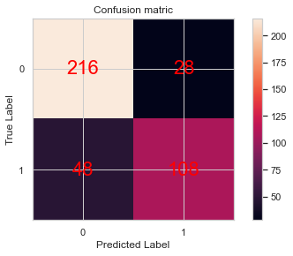

```python
plot_confusion_matrix(cm, np.unique(y_pred))
```

## ROC Curve

```python
# To determine the ROC Curve, First define the metrics.
y_pred_proba = classifier.predict_proba(X_test) [::, 1]
```

```python
# Calculate the true positive and false psositive rates
false_positive_rate, true_positive_rate, _ = metrics.roc_curve(y_test, y_pred_proba)
```

```python
# Calculate the AUC to see the model's performance
auc = metrics.roc_auc_score(y_test, y_pred_proba)
```

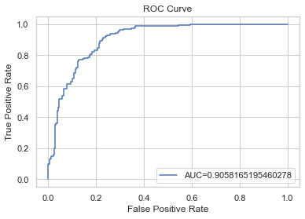

```python
# Plot the ROC Curve.
plt.plot(false_positive_rate, true_positive_rate, label='AUC=' + str(auc))
plt.title('ROC Curve')
plt.xlabel('False Positive Rate')
plt.ylabel('True Positive Rate')
plt.legend(loc=4);
```

### The AUC is 0.91, meaning that the model did a great job

The receiver operating characteristic (ROC) curve is used to display the sensitivity and specificity of the logistic regression model by calculating the true positive and false positive rates.

From the ROC curve, we can calculate the area under the curve (AUC) whose value ranges from 0 to 1. You’ll remember that the closer to 1, the better it is for our predictive modeling.